# Module 10: Data Analysis in Python

## Part 2

```python
#Import Python Libraries
import scipy as sp
import pandas as pd
import matplotlib.pyplot as plt
import seaborn as sns
```

### Missing Values

- Missing values are marked as NaN
- When summing the data, missing values will be treated as zero
- If all values are missing, the sum will be equal to NaN
- cumsum() and cumprod() methods ignore missing values but preserve them in the resulting arrays
- Missing values in GroupBy method are excluded (just like in R)
- Many descriptive statistics methods have skipna option to control if missing data should be excluded . This value is set to True by default (unlike R)

There are a number of methods to deal with missing values in the data frame:

- dropna() - Drop missing observations
- dropna(how='all') - Drop observations where all cells is NA
- dropna(axis=1, how='all') - Drop column if all the values are missing
- dropna(thresh = 5) - Drop rows that contain less than 5 non-missing values
- fillna(0) - Replace missing values with zeros
- isnull() - Returns True if the value is missing
- notnull() - Returns True for non-missing values

```python
# Read a dataset with missing values
flights = pd.read_csv("http://rcs.bu.edu/examples/python/data_analysis/flights.csv")
flights.head()
```

|  | year | month | day | dep_time | dep_delay | arr_time | arr_delay | carrier | tailnum | flight | origin | dest | air_time | distance | hour | minute |
| --- | --- | --- | --- | --- | --- | --- | --- | --- | --- | --- | --- | --- | --- | --- | --- | --- |
| 0 | 2013 | 1 | 1 | 517.0 | 2.0 | 830.0 | 11.0 | UA | N14228 | 1545 | EWR | IAH | 227.0 | 1400 | 5.0 | 17.0 |
| 1 | 2013 | 1 | 1 | 533.0 | 4.0 | 850.0 | 20.0 | UA | N24211 | 1714 | LGA | IAH | 227.0 | 1416 | 5.0 | 33.0 |
| 2 | 2013 | 1 | 1 | 542.0 | 2.0 | 923.0 | 33.0 | AA | N619AA | 1141 | JFK | MIA | 160.0 | 1089 | 5.0 | 42.0 |
| 3 | 2013 | 1 | 1 | 554.0 | -6.0 | 812.0 | -25.0 | DL | N668DN | 461 | LGA | ATL | 116.0 | 762 | 5.0 | 54.0 |
| 4 | 2013 | 1 | 1 | 554.0 | -4.0 | 740.0 | 12.0 | UA | N39463 | 1696 | EWR | ORD | 150.0 | 719 | 5.0 | 54.0 |

```python
# Select the rows that have at least one missing value for dep_time
flights[flights['dep_time'].isnull()].head()
```

|  | year | month | day | dep_time | dep_delay | arr_time | arr_delay | carrier | tailnum | flight | origin | dest | air_time | distance | hour | minute |
| --- | --- | --- | --- | --- | --- | --- | --- | --- | --- | --- | --- | --- | --- | --- | --- | --- |
| 403 | 2013 | 1 | 1 | NaN | NaN | NaN | NaN | AA | N3EHAA | 791 | LGA | DFW | NaN | 1389 | NaN | NaN |
| 404 | 2013 | 1 | 1 | NaN | NaN | NaN | NaN | AA | N3EVAA | 1925 | LGA | MIA | NaN | 1096 | NaN | NaN |
| 858 | 2013 | 1 | 2 | NaN | NaN | NaN | NaN | AA | NaN | 133 | JFK | LAX | NaN | 2475 | NaN | NaN |
| 859 | 2013 | 1 | 2 | NaN | NaN | NaN | NaN | AA | N3FBAA | 753 | LGA | DFW | NaN | 1389 | NaN | NaN |
| 860 | 2013 | 1 | 2 | NaN | NaN | NaN | NaN | UA | NaN | 623 | EWR | ORD | NaN | 719 | NaN | NaN |

```python
# Get a count of the missings in each column
flights.isnull().sum()
```

```
year            0
month           0
day             0
dep_time     2336
dep_delay    2336
arr_time     2479
arr_delay    2827
carrier         0
tailnum      1433
flight          0
origin          0
dest            0
air_time     2827
distance        0
hour         2336
minute       2336
dtype: int64
```

```python
# Filter all the rows where arr_delay value is missing:
flights1 = flights[ flights['arr_delay'].notnull( )]
flights1.head()
```

|  | year | month | day | dep_time | dep_delay | arr_time | arr_delay | carrier | tailnum | flight | origin | dest | air_time | distance | hour | minute |
| --- | --- | --- | --- | --- | --- | --- | --- | --- | --- | --- | --- | --- | --- | --- | --- | --- |
| 0 | 2013 | 1 | 1 | 517.0 | 2.0 | 830.0 | 11.0 | UA | N14228 | 1545 | EWR | IAH | 227.0 | 1400 | 5.0 | 17.0 |
| 1 | 2013 | 1 | 1 | 533.0 | 4.0 | 850.0 | 20.0 | UA | N24211 | 1714 | LGA | IAH | 227.0 | 1416 | 5.0 | 33.0 |
| 2 | 2013 | 1 | 1 | 542.0 | 2.0 | 923.0 | 33.0 | AA | N619AA | 1141 | JFK | MIA | 160.0 | 1089 | 5.0 | 42.0 |
| 3 | 2013 | 1 | 1 | 554.0 | -6.0 | 812.0 | -25.0 | DL | N668DN | 461 | LGA | ATL | 116.0 | 762 | 5.0 | 54.0 |
| 4 | 2013 | 1 | 1 | 554.0 | -4.0 | 740.0 | 12.0 | UA | N39463 | 1696 | EWR | ORD | 150.0 | 719 | 5.0 | 54.0 |

```python
# Check to see the number missing
flights1['arr_delay'].isnull().sum()
```

```
0
```

```python
# Remove all the observations with missing values
flights2 = flights.dropna()
```

### Handons-on Exercise

- Check the flights2 dataset to see if all missing values have been dropped

```python
# Answer
flights2['arr_delay'].isnull().sum()
```

```
0
```

### Aggregation Functions in Pandas

Aggregation - computing a summary statistic about each group, i.e.

- compute group sums or means
- compute group sizes/counts

### Common Aggregation Functions:

| Function | Description |
| --- | --- |
| min | minimum |
| max | maximum |
| count | number of non-null observations |
| sum | sum of values |
| mean | arithmetic mean of values |
| median | median |
| mad | mean absolute deviation |
| mode | mode |
| prod | product of values |
| std | standard deviation |
| var | unbiased variance |

```python
# Let's compute summary statistic per a group':
flights.groupby('carrier')['dep_delay'].mean()
```

```
carrier
AA     8.586016
AS     5.804775
DL     9.264505
UA    12.106073
US     3.782418
Name: dep_delay, dtype: float64
```

agg() method is useful when multiple statistics are computed per column:

```python
# We can use agg() methods for aggregation:
flights[['dep_delay','arr_delay']].agg(['min','mean','max'])
```

|  | dep_delay | arr_delay |
| --- | --- | --- |
| min | -33.000000 | -75.000000 |
| mean | 9.463773 | 2.094537 |
| max | 1014.000000 | 1007.000000 |

```python
# An example of computing different statistics for different columns
flights.agg({'dep_delay':['min','mean',max], 'carrier':['nunique']})
```

|  | dep_delay | carrier |
| --- | --- | --- |
| max | 1014.000000 | NaN |
| mean | 9.463773 | NaN |
| min | -33.000000 | NaN |
| nunique | NaN | 5.0 |

### Hands-On Exercise

- Use agg() & group by to find the mean, median, min, and max air_time, distance, arr_delay & dep_delay for each airline

```python
# Answer
flights.groupby('carrier')[['air_time', 'distance', 'dep_delay', 'arr_delay']].agg(['mean','median','min',max])
```

| carrier | air_time mean | air_time median | air_time min | air_time max | distance mean | distance median | distance min | distance max | dep_delay mean | dep_delay median | dep_delay min | dep_delay max | arr_delay mean | arr_delay median | arr_delay min | arr_delay max |
| --- | --- | --- | --- | --- | --- | --- | --- | --- | --- | --- | --- | --- | --- | --- | --- | --- |
| AA | 188.822299 | 169.0 | 29.0 | 426.0 | 1340.235999 | 1096 | 187 | 2586 | 8.586016 | -3.0 | -24.0 | 1014.0 | 0.364291 | -9.0 | -75.0 | 1007.0 |
| AS | 325.617772 | 324.0 | 277.0 | 392.0 | 2402.000000 | 2402 | 2402 | 2402 | 5.804775 | -3.0 | -21.0 | 225.0 | -9.930889 | -17.0 | -74.0 | 198.0 |
| DL | 173.688804 | 145.0 | 26.0 | 490.0 | 1236.901206 | 1020 | 94 | 2586 | 9.264505 | -2.0 | -33.0 | 960.0 | 1.644341 | -8.0 | -71.0 | 931.0 |
| UA | 211.791354 | 197.0 | 23.0 | 695.0 | 1529.114873 | 1400 | 116 | 4963 | 12.106073 | 0.0 | -20.0 | 483.0 | 3.558011 | -6.0 | -75.0 | 455.0 |
| US | 88.573799 | 76.0 | 21.0 | 359.0 | 553.456272 | 529 | 17 | 2153 | 3.782418 | -4.0 | -19.0 | 500.0 | 2.129595 | -6.0 | -70.0 | 492.0 |

### Explore data using graphics

Seaborn package is built on matplotlib but provides high level interface for drawing attractive statistical graphics, similar to ggplot2 library in R. It specifically targets statistical data visualization

```python
#Show graphs within Python notebook
%matplotlib inline
```

```python
# Read in csv file
df = pd.read_csv("http://rcs.bu.edu/examples/python/data_analysis/Salaries.csv")
```

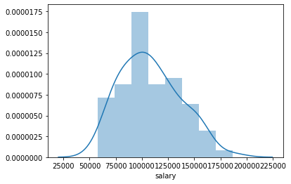

```python
# Use seaborn package to draw a histogram
sns.distplot(df['salary'])
```

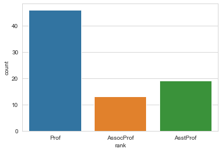

```python
# Use seaborn package to display a bar chart. Can change style as desired
sns.set_style("whitegrid")

ax = sns.countplot(x='rank', data=df)
```

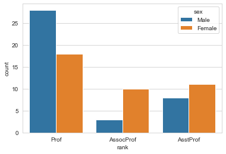

```python
# View count by sex
ax = sns.countplot(x='rank', hue='sex', data=df)
```

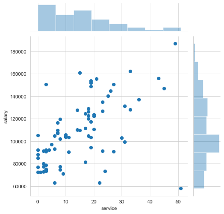

```python
#Scatterplot in seaborn
# Years of service * salary
sns.jointplot(x='service', y='salary', data=df)
```

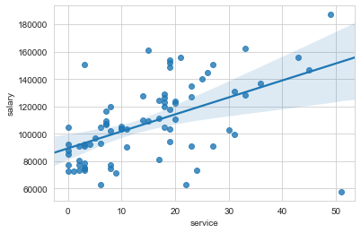

```python
#If we are interested in linear regression plot for 2 numeric variables we can use regplot
sns.regplot(x='service', y='salary', data=df)
```

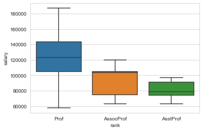

```python
# box plot
sns.boxplot(x='rank',y='salary', data=df)
```

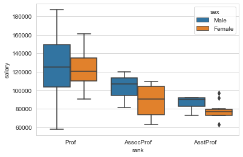

```python
# side-by-side box plot
sns.boxplot(x='rank',y='salary', data=df, hue='sex')
```

### Hands-On Exercise

Using seaborn package, explore the realtionship between dep_delay (x) on arr_delay (y) using the flights dataset

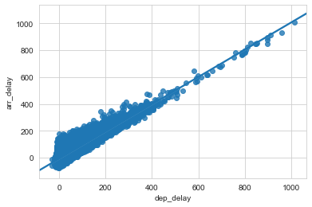

```python
# ANSWER
sns.regplot(x='dep_delay', y='arr_delay', data=flights)
```

## Basic statistical Analysis

### Linear Regression

```python
# Import Statsmodel functions:
import statsmodels.formula.api as smf
```

```python
# create a fitted model
lm = smf.ols(formula='salary ~ service', data=df).fit()

#print model summary
print(lm.summary())
```

```
                            OLS Regression Results
==============================================================================
Dep. Variable:                 salary   R-squared:                       0.283
Model:                            OLS   Adj. R-squared:                  0.274
Method:                 Least Squares   F-statistic:                     30.03
Date:                Mon, 18 Nov 2019   Prob (F-statistic):           5.31e-07
Time:                        20:49:47   Log-Likelihood:                -896.72
No. Observations:                  78   AIC:                             1797.
Df Residuals:                      76   BIC:                             1802.
Df Model:                           1
Covariance Type:            nonrobust
==============================================================================
                 coef    std err          t      P>|t|      [0.025      0.975]
------------------------------------------------------------------------------
Intercept   8.935e+04   4365.651     20.468      0.000    8.07e+04     9.8e+04
service     1240.3567    226.341      5.480      0.000     789.560    1691.153
==============================================================================
Omnibus:                       12.741   Durbin-Watson:                   1.630
Prob(Omnibus):                  0.002   Jarque-Bera (JB):               21.944
Skew:                          -0.576   Prob(JB):                     1.72e-05
Kurtosis:                       5.329   Cond. No.                         30.9
==============================================================================

Warnings:
[1] Standard Errors assume that the covariance matrix of the errors is correctly specified.
```

```python
# print the coefficients
lm.params
```

```
Intercept    89354.824215
service       1240.356654
dtype: float64
```

### Hands-On Exercise

- Build a linear model for arr_delay ~ dep_delay
- Print model summary

```python
# ANSWER
lm = smf.ols(formula='arr_delay ~ dep_delay', data=flights).fit()

#print model summary
print(lm.summary())
```

```
                            OLS Regression Results
==============================================================================
Dep. Variable:              arr_delay   R-squared:                       0.794
Model:                            OLS   Adj. R-squared:                  0.794
Method:                 Least Squares   F-statistic:                 6.074e+05
Date:                Mon, 18 Nov 2019   Prob (F-statistic):               0.00
Time:                        20:49:48   Log-Likelihood:            -6.8778e+05
No. Observations:              157927   AIC:                         1.376e+06
Df Residuals:                  157925   BIC:                         1.376e+06
Df Model:                           1
Covariance Type:            nonrobust
==============================================================================
                 coef    std err          t      P>|t|      [0.025      0.975]
------------------------------------------------------------------------------
Intercept     -7.4457      0.049   -152.050      0.000      -7.542      -7.350
dep_delay      1.0138      0.001    779.358      0.000       1.011       1.016
==============================================================================
Omnibus:                    38155.693   Durbin-Watson:                   1.467
Prob(Omnibus):                  0.000   Jarque-Bera (JB):           159178.104
Skew:                           1.141   Prob(JB):                         0.00
Kurtosis:                       7.357   Cond. No.                         38.9
==============================================================================

Warnings:
[1] Standard Errors assume that the covariance matrix of the errors is correctly specified.
```

### Student T-test

```python
# Using scipy package:
from scipy import stats
df_w = df[ df['sex'] == 'Female']['salary']
df_m = df[ df['sex'] == 'Male']['salary']
stats.ttest_ind(df_w, df_m)
```

```
Ttest_indResult(statistic=-2.2486865976699053, pvalue=0.027429778657910103)
```

```python
# This result shows a significant difference in salary
```

### Hands-on Exercise

- Create a plot/chart that can visualize the result from the t-test above

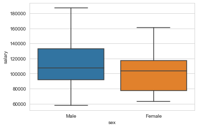

```python
# Answer
sns.boxplot(x='sex', y='salary', data=df)
```

### Final Exercise - Putting things together

- Limit the flights dataset to AA (American Airlines) and UA (United Airlines)
- Find the descriptive stats for the numeric variables
- Create a scatter plot that shows the relationship between distance & airtime
- Run a t-test to find out if there is a significant difference in years of service between males & females

```python
# Answer
#limit the flights to AA and UA
fs = flights[(flights['carrier'] == 'UA')|(flights['carrier'] == 'AA')]
#frequency
fs.carrier.value_counts()
```

```
UA    58665
AA    32729
Name: carrier, dtype: int64
```

```python
# descriptive stats for the numeric variables
fs.describe()
```

|  | year | month | day | dep_time | dep_delay | arr_time | arr_delay | flight | air_time | distance | hour | minute |
| --- | --- | --- | --- | --- | --- | --- | --- | --- | --- | --- | --- | --- |
| count | 91394.0 | 91394.000000 | 91394.000000 | 90072.000000 | 90072.000000 | 89975.000000 | 89729.000000 | 91394.000000 | 89729.000000 | 91394.000000 | 90072.000000 | 90072.000000 |
| mean | 2013.0 | 6.533088 | 15.700593 | 1316.518185 | 10.851863 | 1513.249303 | 2.420923 | 943.912609 | 203.613481 | 1461.475677 | 12.854750 | 31.043232 |
| std | 0.0 | 3.420021 | 8.768155 | 474.922040 | 36.347702 | 518.908035 | 41.564120 | 591.313675 | 95.232319 | 750.616039 | 4.766722 | 18.098799 |
| min | 2013.0 | 1.000000 | 1.000000 | 1.000000 | -24.000000 | 1.000000 | -75.000000 | 1.000000 | 23.000000 | 116.000000 | 0.000000 | 0.000000 |
| 25% | 2013.0 | 4.000000 | 8.000000 | 855.000000 | -4.000000 | 1116.000000 | -20.000000 | 393.000000 | 135.000000 | 937.000000 | 8.000000 | 16.000000 |
| 50% | 2013.0 | 7.000000 | 16.000000 | 1343.000000 | -1.000000 | 1544.000000 | -7.000000 | 881.000000 | 186.000000 | 1389.000000 | 13.000000 | 31.000000 |
| 75% | 2013.0 | 9.000000 | 23.000000 | 1723.000000 | 9.000000 | 1942.000000 | 10.000000 | 1464.000000 | 302.000000 | 2248.000000 | 17.000000 | 48.000000 |
| max | 2013.0 | 12.000000 | 31.000000 | 2400.000000 | 1014.000000 | 2400.000000 | 1007.000000 | 2499.000000 | 695.000000 | 4963.000000 | 24.000000 | 59.000000 |

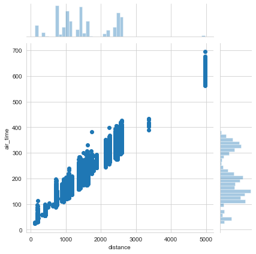

```python
# scatter plot that shows the relationship between distance & airtime
sns.jointplot(x='distance', y='air_time', data=fs)
```

```python
# T-test using scripy
from scipy import stats
df_w = df[ df['sex'] == 'Female']['service']
df_m = df[ df['sex'] == 'Male']['service']
stats.ttest_ind(df_w, df_m)
```

```
Ttest_indResult(statistic=-2.632853656587901, pvalue=0.01025182968368049)
```